# Discover and install useful RStudio addins

[figure not shown]

> Created by [Dean Attali](https://deanattali.com)

[RStudio addins](https://rstudio.github.io/rstudioaddins/) were released in early 2016 to provide anyone with the ability to add “extensions” to RStudio. This feature has quickly become popular, but discoverability was a problem: **there’s just no easy way to know what addins exist.**

The `addinslist` package solves that problem in two ways:

- This package provides a continuously updated list of RStudio addins that you can browse through (below).
- After installing this package (`install.packages('addinslist')`), your RStudio will get populated with a new addin called “Browse RStudio addins”. This addin allows you to interactively browse through the list of addins, see which ones you already have installed, and let you install/uninstall the corresponding package of each addin. The following image shows how to access this “addin of addins” in RStudio.

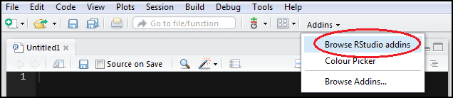

Addins menu

**Need Shiny help? [I’m available for consulting](https://attalitech.com/).**  
**If you find {addinslist} useful, please consider [supporting my work](https://github.com/sponsors/daattali) to unlock rewards! ❤**

## Sponsors 🏆

> There are no sponsors yet

[Become the first sponsor for {addinslist} and unlock special rewards!](https://github.com/sponsors/daattali/sponsorships?tier_id=39856)

## List of addins

If you made a useful RStudio addin, feel free to make a pull request [on GitHub](https://github.com/daattali/addinslist#readme) to add it to the list.

[output not shown]

[output cut: 70 more lines]